# Spatial Regression: Socioeconomic factors and child poverty in Alabama (2016)

# 1 Packages used

I had some difficulty installing a couple of the packages that were on the larger side, namely rgdal and sf. Quitting and restarting R was, for whatever reason, enough to fix the issue.

```r
packages <- c("biscale", "cleangeo", "cowplot", "dplyr", "geosphere",
            "ggplot2", "maps", "maptools", "rgdal", "rgeos", "sf",
            "sp", "spatialreg", "spdep", "tidyr")
sapply(packages, require, character.only=T)
```

```
##    biscale   cleangeo    cowplot      dplyr  geosphere    ggplot2       maps
##       TRUE       TRUE       TRUE       TRUE       TRUE       TRUE       TRUE
##   maptools      rgdal      rgeos         sf         sp spatialreg      spdep
##       TRUE       TRUE       TRUE       TRUE       TRUE       TRUE       TRUE
##      tidyr
##       TRUE
```

# 2 Data

Of course, used the same data as everyone else and renamed the “X2016.child.poverty” column.

```r
data <- read.csv('./Data/childpov18_southfull.csv',
                 colClasses = c("character", "character", "character",
                                "numeric", "numeric", "numeric", "numeric",
                                "numeric", "numeric", "numeric", "numeric",
                                "numeric", "numeric", "numeric", "numeric",
                                "numeric", "numeric", "numeric", "numeric",
                                "numeric", "numeric", "numeric", "numeric",
                                "numeric", "numeric", "numeric", "numeric",
                                "numeric", "numeric", "numeric", "numeric",
                                "numeric", "numeric", "numeric", "numeric"))
names(data)[names(data)=="X2016.child.poverty"] <- "child.pov.2016"
```

## 2.1 Subset for Alabama:

My chosen (?) state - Alabama!

I’ve never been to Alabama and it’s not particularly high up on my travel wish-list. But, a quick Google search revealed some pretty interesting tourist attractions that I’d *consider* visiting Alabama to see!

**National Voting Rights Museum, Selma:**

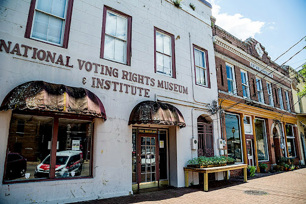

**Weeks Bay National Estuarine Research Reserve, Mobile Bay:**

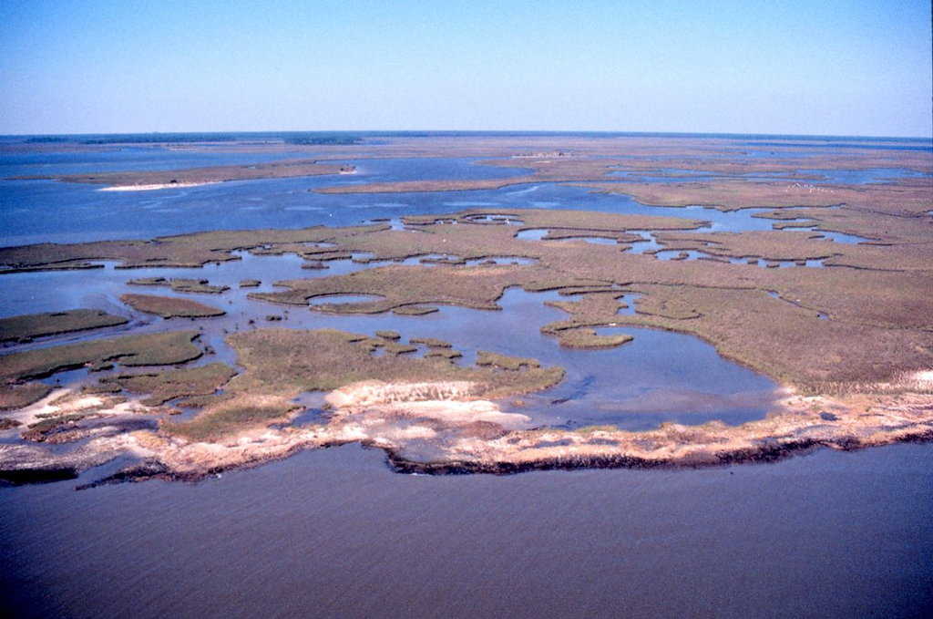

**Birmingham Civil Rights Institute:**

[figure not shown]

```r
al_pov <- data %>% subset(State == "AL")

summary(al_pov)
```

```
##      FIPS              State           County_Name          Longitude
##  Length:67          Length:67          Length:67          Min.   :-88.26
##  Class :character   Class :character   Class :character   1st Qu.:-87.45
##  Mode  :character   Mode  :character   Mode  :character   Median :-86.66
##                                                           Mean   :-86.71
##                                                           3rd Qu.:-85.90
##                                                           Max.   :-85.18
##     Latitude     child.pov.2016  unemployment_13   per_lhs_13
##  Min.   :30.74   Min.   :10.80   Min.   : 4.6    Min.   : 8.80
##  1st Qu.:31.94   1st Qu.:23.80   1st Qu.: 6.9    1st Qu.:18.15
##  Median :32.86   Median :30.00   Median : 7.9    Median :22.40
##  Mean   :32.89   Mean   :31.25   Mean   : 8.5    Mean   :21.07
##  3rd Qu.:33.80   3rd Qu.:36.55   3rd Qu.: 9.2    3rd Qu.:23.95
##  Max.   :34.91   Max.   :62.10   Max.   :19.3    Max.   :32.20
##   per_black_13     per_hispanic_13     per_ag_13       per_construction_13
##  Min.   : 0.5669   Min.   : 0.1561   Min.   : 0.4542   Min.   : 3.349
##  1st Qu.:11.0559   1st Qu.: 1.4277   1st Qu.: 1.5152   1st Qu.: 6.031
##  Median :22.7042   Median : 2.3040   Median : 3.0566   Median : 7.291
##  Mean   :28.3138   Mean   : 3.2081   Mean   : 3.3225   Mean   : 7.636
##  3rd Qu.:41.9734   3rd Qu.: 3.6593   3rd Qu.: 4.2385   3rd Qu.: 8.573
##  Max.   :80.7813   Max.   :15.0508   Max.   :11.1384   Max.   :18.008
##  per_manufacturing_13 per_retail_13    per_healthss_13 per_singlemom_13
##  Min.   : 7.916       Min.   : 7.093   Min.   :13.49   Min.   : 7.300
##  1st Qu.:13.090       1st Qu.:10.721   1st Qu.:18.84   1st Qu.: 9.721
##  Median :18.363       Median :11.863   Median :20.60   Median :11.297
##  Mean   :17.910       Mean   :11.856   Mean   :21.20   Mean   :12.795
##  3rd Qu.:21.106       3rd Qu.:13.061   3rd Qu.:22.90   3rd Qu.:15.360
##  Max.   :32.274       Max.   :16.346   Max.   :34.32   Max.   :22.262
##      urban            rural          lnchildpov    lnunemployment
##  Min.   :0.0000   Min.   :0.0000   Min.   :2.380   Min.   :1.526
##  1st Qu.:0.0000   1st Qu.:0.0000   1st Qu.:3.170   1st Qu.:1.932
##  Median :0.0000   Median :0.0000   Median :3.401   Median :2.067
##  Mean   :0.4328   Mean   :0.1642   Mean   :3.389   Mean   :2.108
##  3rd Qu.:1.0000   3rd Qu.:0.0000   3rd Qu.:3.598   3rd Qu.:2.219
##  Max.   :1.0000   Max.   :1.0000   Max.   :4.129   Max.   :2.960
##     lnlesshs        lnblack          lnhispanic           lnag
##  Min.   :2.175   Min.   :-0.5675   Min.   :-1.8573   Min.   :-0.7892
##  1st Qu.:2.899   1st Qu.: 2.4029   1st Qu.: 0.3561   1st Qu.: 0.4149
##  Median :3.109   Median : 3.1225   Median : 0.8346   Median : 1.1173
##  Mean   :3.017   Mean   : 2.8952   Mean   : 0.8085   Mean   : 0.9477
```

[output cut: 8 more lines]

```
##  Max.   :2.891   Max.   :3.474   Max.   :2.794   Max.   :3.536
##   lnsinglemom      lnchpov17      lnuninsured    lnincome_ratio
##  Min.   :1.988   Min.   :2.313   Min.   :2.424   Min.   :1.382
##  1st Qu.:2.274   1st Qu.:3.180   1st Qu.:2.735   1st Qu.:1.547
##  Median :2.424   Median :3.374   Median :2.799   Median :1.627
##  Mean   :2.501   Mean   :3.368   Mean   :2.797   Mean   :1.627
##  3rd Qu.:2.732   3rd Qu.:3.565   3rd Qu.:2.869   3rd Qu.:1.693
##  Max.   :3.103   Max.   :4.217   Max.   :3.077   Max.   :1.971
##  lnsevere_housing  lnteenbirth     lnunmarried
##  Min.   :2.257    Min.   :3.142   Min.   :2.380
##  1st Qu.:2.520    1st Qu.:3.798   1st Qu.:3.391
##  Median :2.668    Median :3.943   Median :3.721
##  Mean   :2.692    Mean   :3.902   Mean   :3.655
##  3rd Qu.:2.846    3rd Qu.:4.046   3rd Qu.:3.950
##  Max.   :3.280    Max.   :4.438   Max.   :4.593
```

# 3 Ordinary Least Squares Analysis

First, I created the equation to try and explain child poverty with our variables, as well as limited the scientific notation and ran the OLS.

```r
equation <- child.pov.2016 ~ rural + urban + lnmanufacturing + lnag +
  lnretail + lnhealthss + lnconstruction + lnlesshs +
  lnunemployment + lnsinglemom + lnblack + lnhispanic +
  lnuninsured + lnincome_ratio + lnteenbirth + lnunmarried

options(scipen = 5)

ols <- lm(equation, data=al_pov)
summary(ols)
```

```
##
## Call:
## lm(formula = equation, data = al_pov)
##
## Residuals:
##      Min       1Q   Median       3Q      Max
## -12.0557  -3.1371  -0.7005   3.0650  12.1511
##
## Coefficients:
##                  Estimate Std. Error t value  Pr(>|t|)
## (Intercept)     -113.5396    40.3705  -2.812   0.00701 **
## rural              3.3447     2.7547   1.214   0.23038
## urban             -3.2229     2.0859  -1.545   0.12863
## lnmanufacturing   -1.0017     4.0259  -0.249   0.80453
## lnag              -0.3857     1.4348  -0.269   0.78917
## lnretail           3.7767     5.5630   0.679   0.50033
## lnhealthss        14.3452     6.4672   2.218   0.03112 *
## lnconstruction     5.5326     3.1442   1.760   0.08459 .
## lnlesshs           8.1630     6.9808   1.169   0.24780
## lnunemployment    26.7752     6.2516   4.283 0.0000836 ***
## lnsinglemom       14.9424     5.5171   2.708   0.00923 **
## lnblack            0.1851     1.3324   0.139   0.89008
## lnhispanic         4.3926     1.5490   2.836   0.00658 **
## lnuninsured       -9.8133    11.1783  -0.878   0.38420
## lnincome_ratio   -16.6102     9.9559  -1.668   0.10149
## lnteenbirth        3.7111     4.9205   0.754   0.45425
## lnunmarried        0.6630     2.2003   0.301   0.76443
## ---
## Signif. codes:  0 '***' 0.001 '**' 0.01 '*' 0.05 '.' 0.1 ' ' 1
##
## Residual standard error: 5.854 on 50 degrees of freedom
## Multiple R-squared:  0.7597, Adjusted R-squared:  0.6828
## F-statistic: 9.881 on 16 and 50 DF,  p-value: 1.769e-10
```

As we can see from our first analysis using ordinary least squares, child poverty in Alabama appears to be related strongly to four variables: employment of the child’s parents in the healthcare industry, whether the child’s parents are unemployed, single mothers and whether the child is of hispanic descent.

Of these four variables, unemployment is both the most significant and has the largest contribution to child poverty out of all of our examined variables.

# 4 Contiguity

To test for spatial relationships in the data I used the “queens” case for neighbors.

## 4.1 Creating a list of neighbors

First, we need to add the FIPS column that will allow us to merge our spatial and poverty data by creating the set of polygons and their corresponding FIPS. The code below will also allow us to create a list of neighbors

```r
fips <- county.fips
fips.codes <- separate(data = fips, col = polyname, into = c("state", "county"), sep = ",")
al_fips <- subset(fips.codes, state=="alabama", select=fips)

alabama <- map(database = "county", regions = "alabama", fill=T, plot=F)
alabama_sp = map2SpatialPolygons(alabama,al_fips$fips,CRS("+proj=longlat"))
```

I didn’t actually observe any errors when creating the set of neighbors (because I didn’t try it before cleaning it) but figured that cleaning the data anyway couldn’t hurt:

```r
cleaned <- clgeo_Clean(alabama_sp)
neighb.data <- poly2nb(cleaned, queen=T)
cont.neighb <- nb2listw(neighb.data,style="W", zero.policy = TRUE)
```

Now we’ve officially created a spatial dataset and a list of neighbors - so, we’re ready to see if there’s any residual spatial dependence.

## 4.2 Moran’s Correlation / LaGrange Multiplier Tests

To begin testing whether or not spatial dependence is an important component to add to our model, I of course began by using a Moran’s Correlation Test to examine the residuals from the OLS regression with the spatial relationship matrix we just created above.

```r
lm.morantest(ols, cont.neighb)
```

```
##
##  Global Moran I for regression residuals
##
## data:
## model: lm(formula = equation, data = al_pov)
## weights: cont.neighb
##
## Moran I statistic standard deviate = 0.23855, p-value = 0.4057
## alternative hypothesis: greater
## sample estimates:
## Observed Moran I      Expectation         Variance
##     -0.030257298     -0.047158474      0.005019763
```

Non-significant p-value and therefore can’t reject the null hypothesis (no spatial correlations in the residuals). So, it’s likely not necessary to attempt a spatial model at all - the OLS results model the data fine!

But, let’s follow Dr. Luc Anselin’s advice and use a LaGrange Multiplier Test to see the resulting estimates for the linear model tests:

```r
lm.LMtests(ols, cont.neighb, test="all")
```

```
##
##  Lagrange multiplier diagnostics for spatial dependence
##
## data:
## model: lm(formula = equation, data = al_pov)
## weights: cont.neighb
##
## LMerr = 0.14972, df = 1, p-value = 0.6988
##
##
##  Lagrange multiplier diagnostics for spatial dependence
##
## data:
## model: lm(formula = equation, data = al_pov)
## weights: cont.neighb
##
## LMlag = 0.63646, df = 1, p-value = 0.425
##
##
##  Lagrange multiplier diagnostics for spatial dependence
##
## data:
## model: lm(formula = equation, data = al_pov)
## weights: cont.neighb
##
## RLMerr = 1.848, df = 1, p-value = 0.174
##
##
##  Lagrange multiplier diagnostics for spatial dependence
##
## data:
## model: lm(formula = equation, data = al_pov)
## weights: cont.neighb
##
## RLMlag = 2.3347, df = 1, p-value = 0.1265
##
##
##  Lagrange multiplier diagnostics for spatial dependence
##
## data:
## model: lm(formula = equation, data = al_pov)
## weights: cont.neighb
##
## SARMA = 2.4844, df = 2, p-value = 0.2887
```

With strictly non-significant p-values resulting from the LaGrange test we’re led to believe that none of the models included in the test would be a suitable fit for modeling the socioeconomic factors we have for Alabama and how they correlate with child poverty.

So, we’ll retain our OLS results and move onto mapping these (without incorporating an effect from neighbors into our model).

# 5 Mapping

## 5.1 Bivariate map of child poverty and unemployment

```r
#dist.err.data <- summary(all.dist.err.k1, correlation=TRUE, Nagelkerke = TRUE)

al.output <- cbind.data.frame(al_pov$FIPS,
                                al_pov$child.pov.2016,
                                al_pov$lnhealthss,
                                al_pov$lnunemployment,
                                al_pov$lnsinglemom,
                                al_pov$lnhispanic,
                                stringsAsFactors = FALSE)

#Renaming columns
colnames(al.output) <- c("fips","child_pov","healthss",
                        "unemployed","single_mom","hispanic")
```

Next, let’s create our data and make a legend:

```r
al_fortify <- fortify(alabama_sp)

al_poly <- merge(x = al_fortify, y = al.output,
                 by.x = "id", by.y = "fips", all = TRUE)

bivariate_data_unemployed <- bi_class(al_poly, x = child_pov, y = unemployed,
                           dim = 3, style = "quantile")

legend <- bi_legend(pal = "DkViolet",
                    dim = 3,
                    xlab = "Child Poverty",
                    ylab = "Unemployment",
                    size = 6)
```

Create additional datasets to serve as a basemap:

```r
world <- map_data("world")
states <- map_data("state")
southern_states <- subset(states, region %in%
                            c("texas", "arkansas", "louisiana", "mississippi",
                              "alabama", "georgia", "florida", "north carolina",
                              "south carolina", "tennessee", "oklahoma",
                              "kentucky", "west virginia", "virginia",
                              "maryland", "delaware", "district of columbia"))
```

Now use ggplot to create the bivariate map:

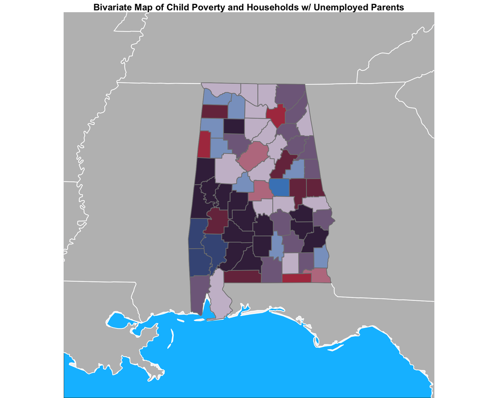

```r
unemployed_pov_map <- ggplot() +
  geom_polygon(data = world, aes(x=long,y=lat, group=group), fill = "gray95", color = "white") +
  geom_polygon(data = states, aes(x=long,y=lat, group=group), fill = "gray", color = "white") +
  geom_polygon(data = southern_states, aes(x=long,y=lat, group=group), fill = NA, size = 0.01, color = "white") +
  geom_polygon(data = bivariate_data_unemployed, aes(x=long, y=lat, group=group, fill = bi_class), color = "grey50", show.legend = FALSE) +
  bi_scale_fill(pal = "DkViolet", dim = 3) +
  coord_map("conic", lat0 = 20, xlim=c(-91,-83), ylim=c(29,36)) +
  theme_void() + theme(legend.title.align=0.5) +
  theme(panel.background = element_rect(fill = 'deepskyblue'),
        panel.grid.major = element_line(colour = NA)) +
  labs(x = "Longitude", y = "Latitude", fill = "Child Poverty",
       title = "Bivariate Map of Child Poverty and Households w/ Unemployed Parents") +
  theme(plot.title = element_text(face = "bold", hjust = 0.5))
unemployed_pov_map
```

Add legend:

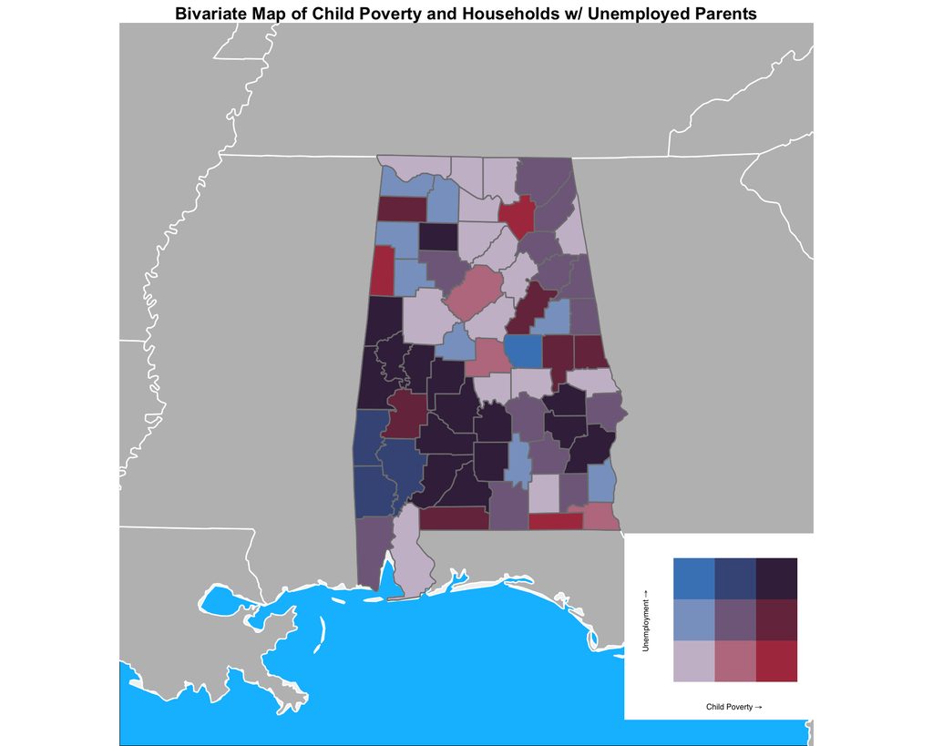

```r
final_unemployed_map <- ggdraw() +
  draw_plot(unemployed_pov_map, 0, 0, 1, 1) +
  draw_plot(legend, 0.65, 0.035, 0.25, 0.25)
final_unemployed_map
```

## 5.2 Child poverty and hispanic descent

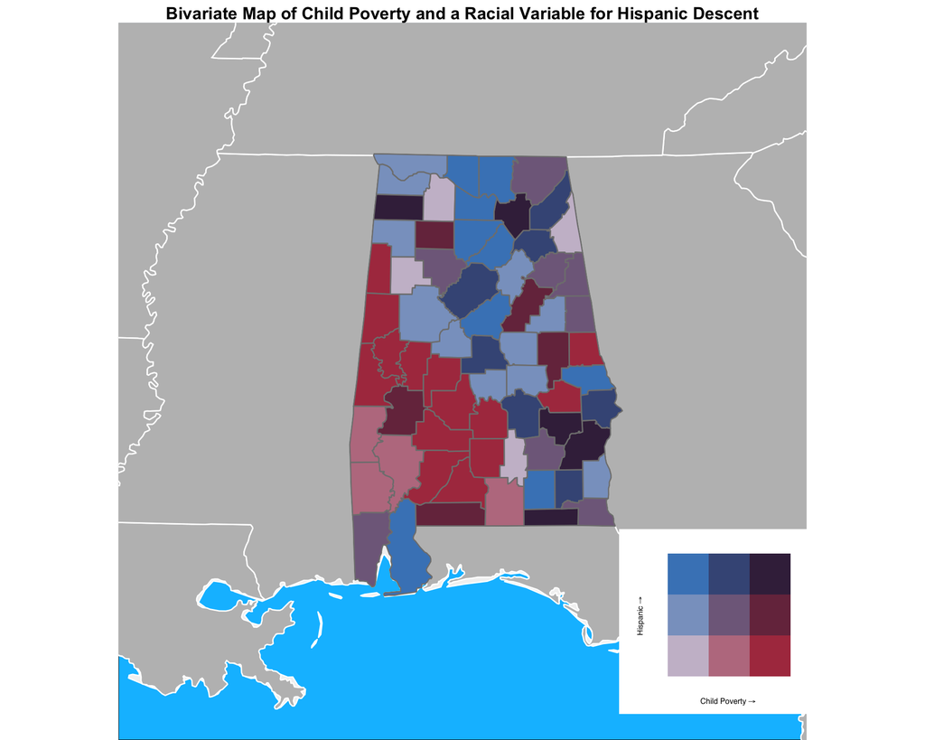

```r
bivariate_data_hispanic <- bi_class(al_poly, x = child_pov, y = hispanic,
                           dim = 3, style = "quantile")

legend.hispanic <- bi_legend(pal = "DkViolet",
                    dim = 3,
                    xlab = "Child Poverty",
                    ylab = "Hispanic",
                    size = 6)

hispanic_pov_map <- ggplot() +
  geom_polygon(data = world, aes(x=long,y=lat, group=group), fill = "gray95", color = "white") +
  geom_polygon(data = states, aes(x=long,y=lat, group=group), fill = "gray", color = "white") +
  geom_polygon(data = southern_states, aes(x=long,y=lat, group=group), fill = NA, size = 0.01, color = "white") +
  geom_polygon(data = bivariate_data_hispanic, aes(x=long, y=lat, group=group, fill = bi_class), color = "grey50", show.legend = FALSE) +
  bi_scale_fill(pal = "DkViolet", dim = 3) +
  coord_map("conic", lat0 = 20, xlim=c(-91,-83), ylim=c(29,36)) +
  theme_void() + theme(legend.title.align=0.5) +
  theme(panel.background = element_rect(fill = 'deepskyblue'),
        panel.grid.major = element_line(colour = NA)) +
  labs(x = "Longitude", y = "Latitude", fill = "hispanic",
       title = "Bivariate Map of Child Poverty and a Racial Variable for Hispanic Descent") +
  theme(plot.title = element_text(face = "bold", hjust = 0.5))

final_hispanic_map <- ggdraw() +
  draw_plot(hispanic_pov_map, 0, 0, 1, 1) +
  draw_plot(legend.hispanic, 0.65, 0.035, 0.25, 0.25)
final_hispanic_map
```

## 5.3 Child poverty and single mother households

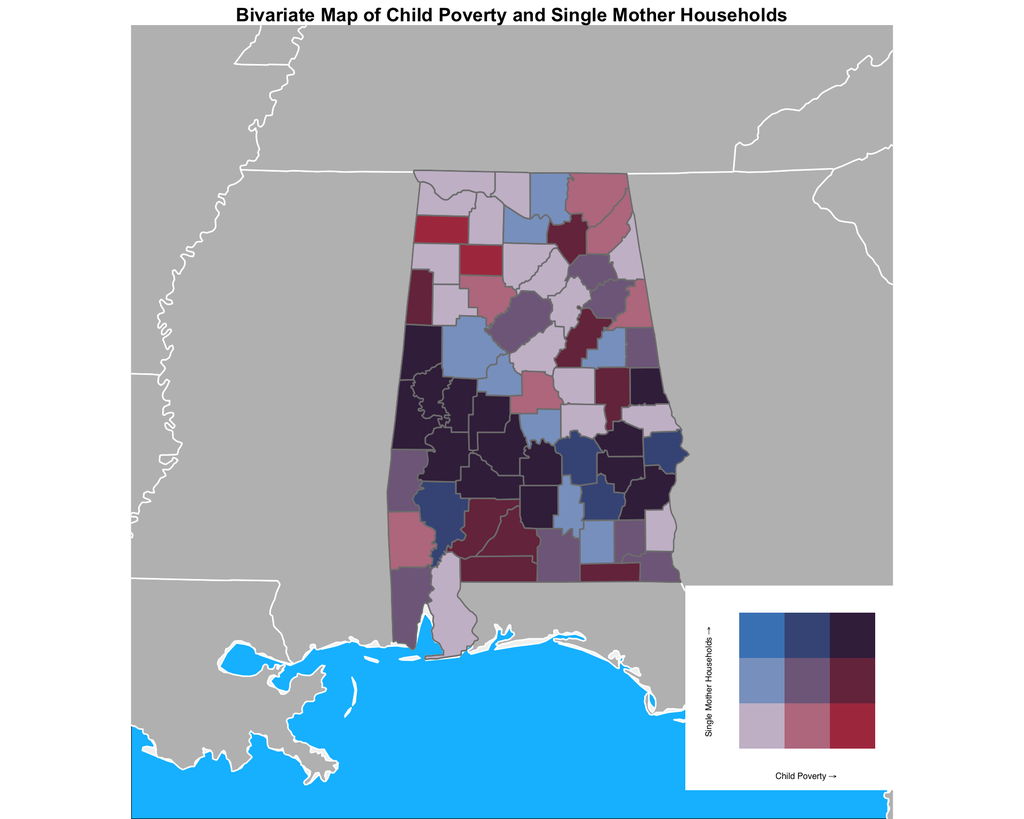

```r
bivariate_data_moms <- bi_class(al_poly, x = child_pov, y = single_mom,
                           dim = 3, style = "quantile")

legend.moms <- bi_legend(pal = "DkViolet",
                    dim = 3,
                    xlab = "Child Poverty",
                    ylab = "Single Mother Households",
                    size = 6)

moms_pov_map <- ggplot() +
  geom_polygon(data = world, aes(x=long,y=lat, group=group), fill = "gray95", color = "white") +
  geom_polygon(data = states, aes(x=long,y=lat, group=group), fill = "gray", color = "white") +
  geom_polygon(data = southern_states, aes(x=long,y=lat, group=group), fill = NA, size = 0.01, color = "white") +
  geom_polygon(data = bivariate_data_moms, aes(x=long, y=lat, group=group, fill = bi_class), color = "grey50", show.legend = FALSE) +
  bi_scale_fill(pal = "DkViolet", dim = 3) +
  coord_map("conic", lat0 = 20, xlim=c(-91,-83), ylim=c(29,36)) +
  theme_void() + theme(legend.title.align=0.5) +
  theme(panel.background = element_rect(fill = 'deepskyblue'),
        panel.grid.major = element_line(colour = NA)) +
  labs(x = "Longitude", y = "Latitude", fill = "single_moms",
       title = "Bivariate Map of Child Poverty and Single Mother Households") +
  theme(plot.title = element_text(face = "bold", hjust = 0.5))

final_moms_map <- ggdraw() +
  draw_plot(moms_pov_map, 0, 0, 1, 1) +
  draw_plot(legend.moms, 0.65, 0.035, 0.25, 0.25)
final_moms_map
```

## 5.4 Child poverty and emplyment in the healthcare industry

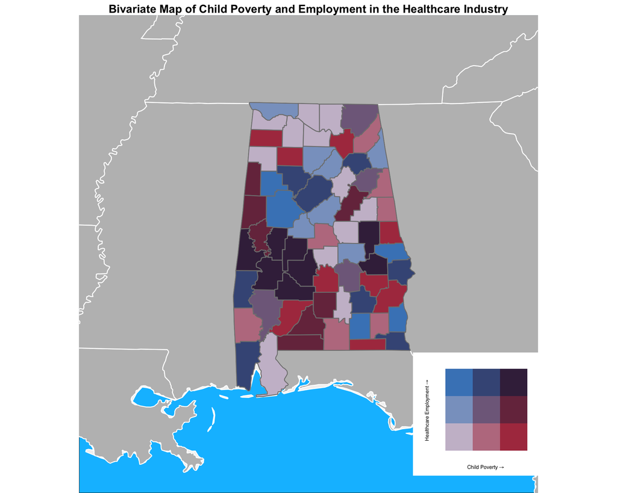

```r
bivariate_data_health <- bi_class(al_poly, x = child_pov, y = healthss,
                           dim = 3, style = "quantile")

legend.health <- bi_legend(pal = "DkViolet",
                    dim = 3,
                    xlab = "Child Poverty",
                    ylab = "Healthcare Employment",
                    size = 6)

health_pov_map <- ggplot() +
  geom_polygon(data = world, aes(x=long,y=lat, group=group), fill = "gray95", color = "white") +
  geom_polygon(data = states, aes(x=long,y=lat, group=group), fill = "gray", color = "white") +
  geom_polygon(data = southern_states, aes(x=long,y=lat, group=group), fill = NA, size = 0.01, color = "white") +
  geom_polygon(data = bivariate_data_health, aes(x=long, y=lat, group=group, fill = bi_class), color = "grey50", show.legend = FALSE) +
  bi_scale_fill(pal = "DkViolet", dim = 3) +
  coord_map("conic", lat0 = 20, xlim=c(-91,-83), ylim=c(29,36)) +
  theme_void() + theme(legend.title.align=0.5) +
  theme(panel.background = element_rect(fill = 'deepskyblue'),
        panel.grid.major = element_line(colour = NA)) +
  labs(x = "Longitude", y = "Latitude", fill = "healthss",
       title = "Bivariate Map of Child Poverty and Employment in the Healthcare Industry") +
  theme(plot.title = element_text(face = "bold", hjust = 0.5))

final_health_map <- ggdraw() +
  draw_plot(health_pov_map, 0, 0, 1, 1) +
  draw_plot(legend.health, 0.65, 0.035, 0.25, 0.25)
final_health_map
```